# Problem set 4: The EITC and diff-in-diff

Jamie Esmond

March 07, 2023

In 1996, Nada Eissa and Jeffrey B. Liebman published a now-classic study on the effect of the Earned Income Tax Credit (EITC) on employment. The EITC is a special tax credit for low income workers that changes depending on (1) how much a family earns (the lowest earners and highest earners don’t receive a huge credit, as the amount received phases in and out), and (2) the number of children a family has (more kids = higher credit). See [this brief explanation](https://www.cbpp.org/research/federal-tax/policy-basics-the-earned-income-tax-credit) for an interactive summary of how the EITC works.

Eissa and Liebman’s study looked at the effects of the EITC on women’s employment and wages after it was initially substantially expanded in 1986. The credit was expanded substantially again in 1993. For this problem set, you’ll measure the causal effect of this 1993 expansion on the employment levels and annual income for women.

A family must have children in order to quality for the EITC, which means the presence of 1 or more kids in a family assigns low-income families to the EITC program (or “treatment”). We have annual data on earnings from 1991–1996, and because the expansion of EITC occurred in 1993, we also have data both before and after the expansion. This treatment/control before/after situation allows us to use a difference-in-differences approach to identify the causal effect of the EITC.

```r
library(tidyverse)  # For ggplot, %>%, mutate, filter, group_by, and friends
library(haven)      # For loading data from Stata
library(broom)      # For showing models as data frames

# This turns off this message that appears whenever you use summarize():
# `summarise()` ungrouping output (override with `.groups` argument)
options(dplyr.summarise.inform = FALSE)

# Load EITC data
eitc <- read_stata("data/eitc.dta") %>%
  # case_when() is a fancy version of ifelse() that takes multiple conditions
  # and outcomes. Here, we make a new variable named children_cat(egorical)
  # with three different levels: 0, 1, and 2+
  mutate(children_cat = case_when(
    children == 0 ~ "0",
    children == 1 ~ "1",
    children >= 2 ~ "2+"
  ))
```

# 1. Exploratory data analysis

Create a new variable that shows if women have 0 children, 1 child, or 2+ children (I did this for you already above).

What is the average of `work`, `finc`, `earn`, `nonwhite`, `ed`, and `age` across each of these different levels of children? How are these groups different? Describe your findings in a paragraph.

## Work

```r
# Work
eitc %>%
  group_by(children_cat) %>%
  summarize(avg_work = mean(work))
```

```
## # A tibble: 3 × 2
##   children_cat avg_work
##   <chr>           <dbl>
## 1 0               0.574
## 2 1               0.538
## 3 2+              0.421
```

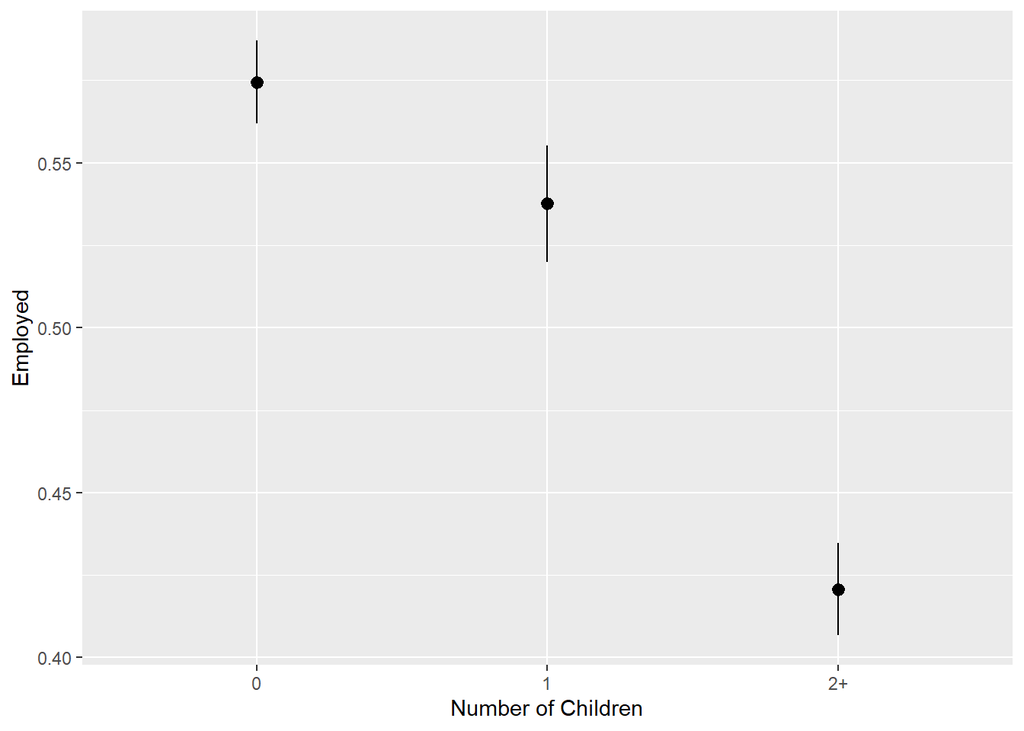

```r
# stat_summary() here is a little different from the geom_*() layers you've seen
# in the past. stat_summary() takes a function (here mean_se()) and runs it on
# each of the children_cat groups to get the average and standard error. It then
# plots those with geom_pointrange. The fun.args part of this lets us pass an
# argument to mean_se() so that we can multiply the standard error by 1.96,
# giving us the 95% confidence interval
ggplot(eitc, aes(x = children_cat, y = work)) +
  stat_summary(geom = "pointrange", fun.data = "mean_se", fun.args = list(mult = 1.96)) +
  labs(x = "Number of Children",
       y = "Employed")
```

## Family income

```r
eitc %>%
  group_by(children_cat) %>%
  summarize(avg_work = mean(finc))
```

```
## # A tibble: 3 × 2
##   children_cat avg_work
##   <chr>           <dbl>
## 1 0              18560.
## 2 1              13942.
## 3 2+             11985.
```

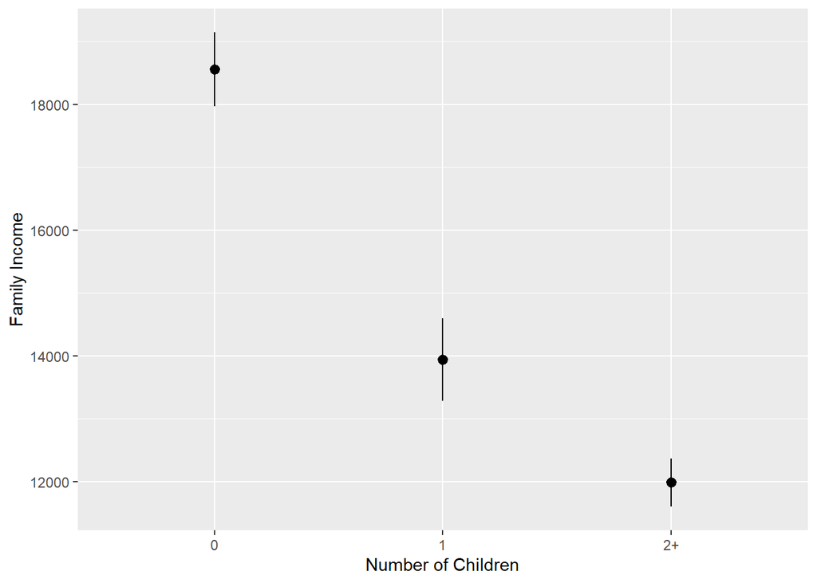

```r
ggplot(eitc, aes(x = children_cat, y = finc)) +
  stat_summary(geom = "pointrange", fun.data = "mean_se", fun.args = list(mult = 1.96)) +
  labs(x = "Number of Children",
       y = "Family Income")
```

## Earnings

```r
eitc %>%
  group_by(children_cat) %>%
  summarize(avg_work = mean(earn))
```

```
## # A tibble: 3 × 2
##   children_cat avg_work
##   <chr>           <dbl>
## 1 0              13760.
## 2 1               9928.
## 3 2+              6614.
```

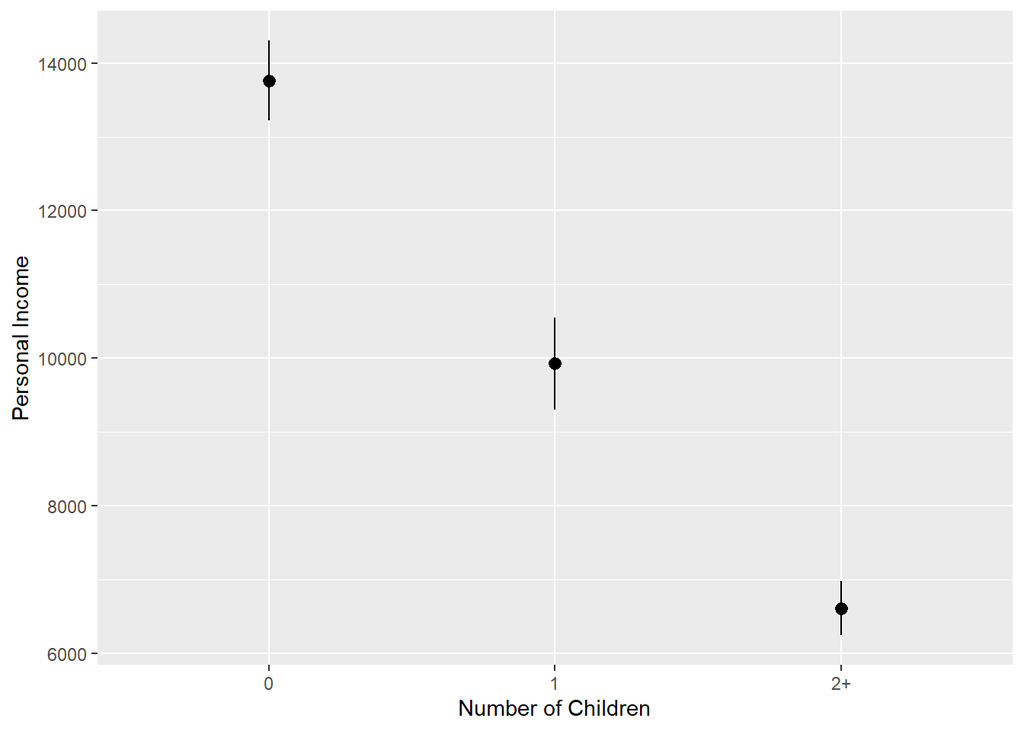

```r
ggplot(eitc, aes(x = children_cat, y = earn)) +
  stat_summary(geom = "pointrange", fun.data = "mean_se", fun.args = list(mult = 1.96)) +
  labs(x = "Number of Children",
       y = "Personal Income")
```

## Race

```r
eitc %>%
  group_by(children_cat) %>%
  summarize(avg_work = mean(nonwhite))
```

```
## # A tibble: 3 × 2
##   children_cat avg_work
##   <chr>           <dbl>
## 1 0               0.516
## 2 1               0.596
## 3 2+              0.709
```

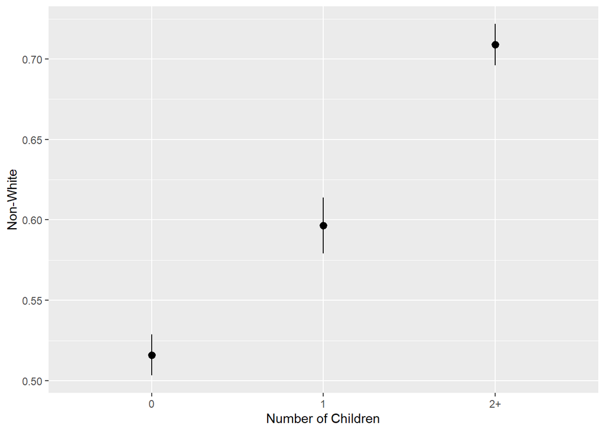

```r
ggplot(eitc, aes(x = children_cat, y = nonwhite)) +
  stat_summary(geom = "pointrange", fun.data = "mean_se", fun.args = list(mult = 1.96)) +
  labs(x = "Number of Children",
       y = "Non-White")
```

## Education

```r
eitc %>%
  group_by(children_cat) %>%
  summarize(avg_work = mean(ed))
```

```
## # A tibble: 3 × 2
##   children_cat avg_work
##   <chr>           <dbl>
## 1 0                8.55
## 2 1                8.99
## 3 2+               9.01
```

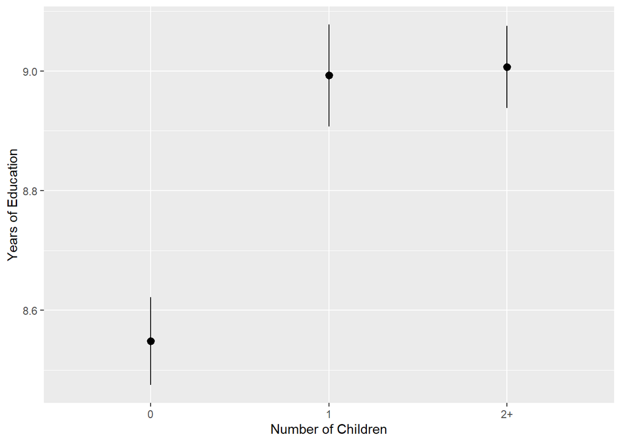

```r
ggplot(eitc, aes(x = children_cat, y = ed)) +
  stat_summary(geom = "pointrange", fun.data = "mean_se", fun.args = list(mult = 1.96)) +
  labs(x = "Number of Children",
       y = "Years of Education")
```

## Age

```r
eitc %>%
  group_by(children_cat) %>%
  summarize(avg_work = mean(age))
```

```
## # A tibble: 3 × 2
##   children_cat avg_work
##   <chr>           <dbl>
## 1 0                38.5
## 2 1                33.8
## 3 2+               32.0
```

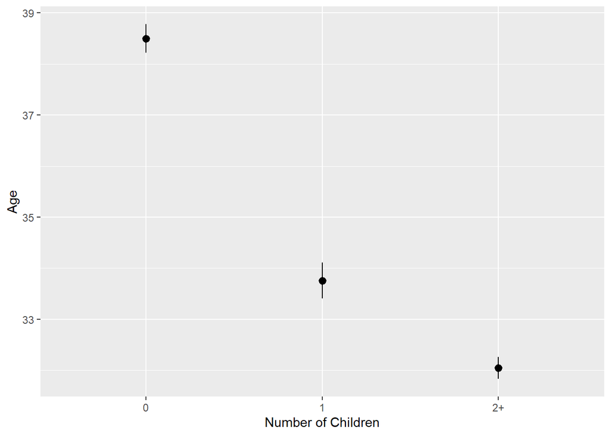

```r
ggplot(eitc, aes(x = children_cat, y = age)) +
  stat_summary(geom = "pointrange", fun.data = "mean_se", fun.args = list(mult = 1.96)) +
  labs(x = "Number of Children",
       y = "Age")
```

## General summary

**Describe your findings in a paragraph. How do these women differ depending on the number of kids they have?**

Women in the sample are less likely to be employed if they have children, the difference is even greater if she has more than one child. These women differ economically depending on the number children they have. Both family and person income is much higher for women without children, and increasingly lower for more than one child. Women with more than one child are much more likely to be non-white. There is almost a 10 percentage point difference for white and non-white women between those with no children, with one child, and with more than one child. A woman having children is correlated with more years of education, but the number of children does not influence the level of education. Women with no children tend to be older than women with children; women with more than one child are even younger on average.

# 2. Create treatment variables

Create a new variable for treatment named `any_kids` (should be TRUE or 1 if `children` > 0) and a variable for the timing named `after_1993` (should be TRUE or 1 if `year` > 1993).

Remember you can use the following syntax for creating a new binary variable based on a test:

```r
new_dataset <- original_dataset %>%
  mutate(new_variable = some_column > some_number)
```

```r
# Make new dataset here.

eitc1 <- eitc %>%
  mutate(any_kids = case_when(children > 0 ~ TRUE,
                              children == 0 ~ FALSE),
         after_1993 = case_when(year > 1993 ~ TRUE,
                                year <= 1993 ~ FALSE))
```

# 3. Check pre- and post-treatment trends

Create a new dataset that shows the average proportion of employed women (`work`) for every year in both the treatment and control groups (i.e. both with and without kids). (Hint: use `group_by()` and `summarize()`, and group by both `year` and `any_kids`.)

```r
# Find average of work across year and any_kids
# Store this as a new object and then print it, like so:
#
eitc_by_year_kids <- eitc1 %>%
  group_by(year, any_kids) %>%
  summarise(workmean = mean(work))

print(eitc_by_year_kids)
```

```
## # A tibble: 12 × 3
## # Groups:   year [6]
##     year any_kids workmean
##    <dbl> <lgl>       <dbl>
##  1  1991 FALSE       0.583
##  2  1991 TRUE        0.460
##  3  1992 FALSE       0.572
##  4  1992 TRUE        0.439
##  5  1993 FALSE       0.571
##  6  1993 TRUE        0.438
##  7  1994 FALSE       0.591
##  8  1994 TRUE        0.464
##  9  1995 FALSE       0.574
## 10  1995 TRUE        0.508
## 11  1996 FALSE       0.552
## 12  1996 TRUE        0.503
```

Plot these trends using colored lines and points, with year on the x-axis, average employment on the y-axis. Add a vertical line at 1994 (hint: use `geom_vline(xintercept = SOMETHING)`.

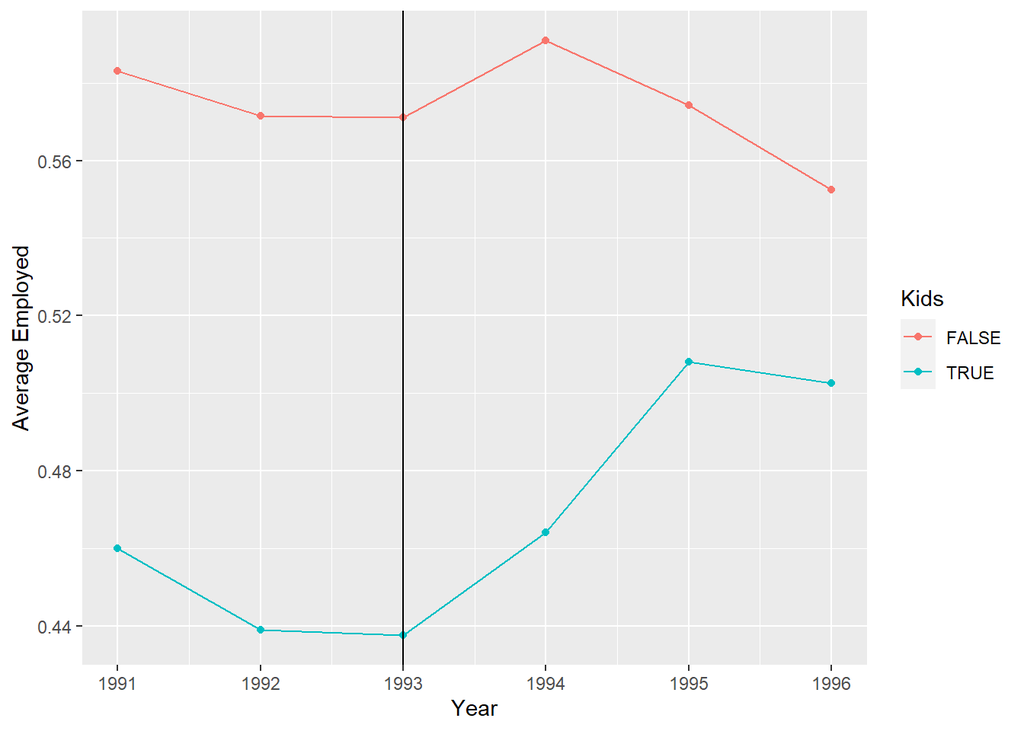

```r
# Add plot here, with x = year, y = average employment, and color = any_kids.
# Add a vertical line too.

eitc_by_year_kids %>%
  group_by(any_kids) %>%
  ggplot(aes(year, workmean, color = any_kids)) +
    geom_line() +
    geom_point() +
    geom_vline(xintercept = 1993) +
    labs(x = "Year",
         y = "Average Employed",
         color = "Kids")
```

**Do the pre-treatment trends appear to be similar?**

Yes, they both decrease in 1992 and held steading in 1993.